# Multiple linear regression

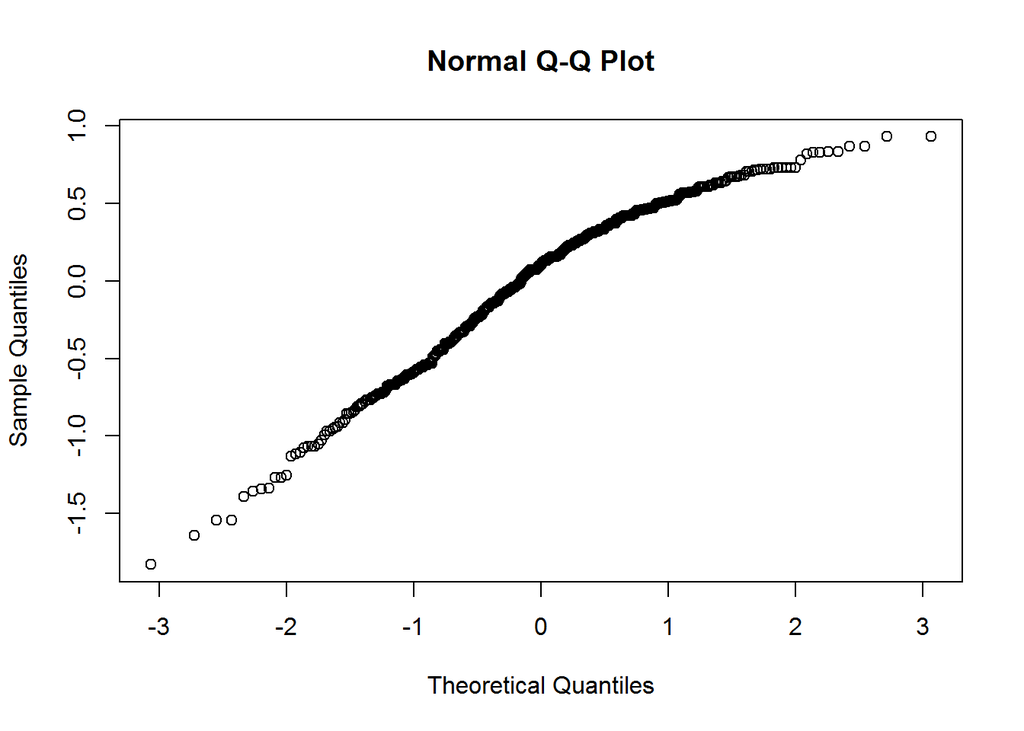

```r
qqnorm(m_bty_gen$residuals)
```

8. Is `bty_avg` still a significant predictor of `score`? Has the addition of `gender` to the model changed the parameter estimate for `bty_avg`?

**Answer: From the fitted model summary we can say the avg beauty is still a significant predictor of the score (P value is statistically significant). Addition of the gender to the model has changed the coefficient value of beauty avg parameter**

Note that the estimate for `gender` is now called `gendermale`. You’ll see this name change whenever you introduce a categorical variable. The reason is that R recodes `gender` from having the values of `female` and `male` to being an indicator variable called `gendermale` that takes a value of $0$ for females and a value of $1$ for males. (Such variables are often referred to as “dummy” variables.)

As a result, for females, the parameter estimate is multiplied by zero, leaving the intercept and slope form familiar from simple regression.

$$\begin{aligned}
\widehat{score} &= \hat{\beta}_0 + \hat{\beta}_1 \times bty\_avg + \hat{\beta}_2 \times (0) \\
&= \hat{\beta}_0 + \hat{\beta}_1 \times bty\_avg\end{aligned}$$

We can plot this line and the line corresponding to males with the following custom function.

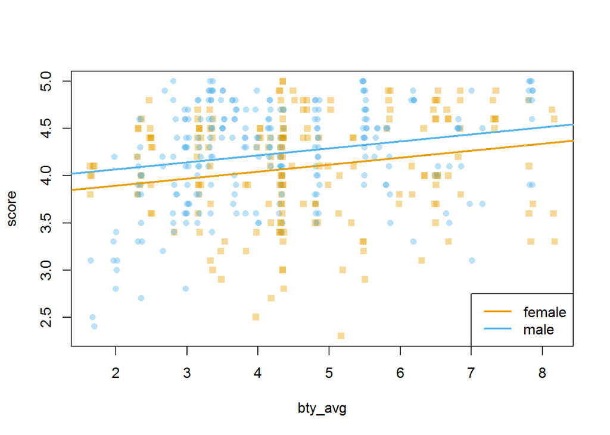

```r
multiLines(m_bty_gen)
```

9. What is the equation of the line corresponding to males? (*Hint:* For males, the parameter estimate is multiplied by 1.) For two professors who received the same beauty rating, which gender tends to have the higher course evaluation score?

**Answer: The linear model equation for males can be written as score = 3.74 + (0.07 * beauty avg) + (0.17 * 1) From this equation we can see that for the same avg beauty, male gender receives 0.17 more avg score compared to female gender**

The decision to call the indicator variable `gendermale` instead of`genderfemale` has no deeper meaning. R simply codes the category that comes first alphabetically as a $0$. (You can change the reference level of a categorical variable, which is the level that is coded as a 0, using the`relevel` function. Use `?relevel` to learn more.)

10. Create a new model called `m_bty_rank` with `gender` removed and `rank` added in. How does R appear to handle categorical variables that have more than two levels? Note that the rank variable has three levels: `teaching`, `tenure track`, `tenured`.

```r
m_bty_rank <- lm(score ~ bty_avg + rank, data = evals)
summary(m_bty_rank)
```

```
##
## Call:
## lm(formula = score ~ bty_avg + rank, data = evals)
##
## Residuals:
##     Min      1Q  Median      3Q     Max
## -1.8713 -0.3642  0.1489  0.4103  0.9525
##
## Coefficients:
##                  Estimate Std. Error t value Pr(>|t|)
## (Intercept)       3.98155    0.09078  43.860  < 2e-16 ***
## bty_avg           0.06783    0.01655   4.098 4.92e-05 ***
## ranktenure track -0.16070    0.07395  -2.173   0.0303 *
## ranktenured      -0.12623    0.06266  -2.014   0.0445 *
## ---
## Signif. codes:  0 '***' 0.001 '**' 0.01 '*' 0.05 '.' 0.1 ' ' 1
##
## Residual standard error: 0.5328 on 459 degrees of freedom
## Multiple R-squared:  0.04652,    Adjusted R-squared:  0.04029
## F-statistic: 7.465 on 3 and 459 DF,  p-value: 6.88e-05
```

**Answer: R uses one hot encoding for handling categorical variable. From the regression coefficient we can see that R has automatically added rank tenuretrak and rank tenured variables to the regression equation. rank teaching is excluded since it can be represented as 0 coefficient. We can interpret the above result as follows**

** 1] If teacher is ranked teaching then each increase in avg beauty of the teacher results in 0.06783 increase in avg score**

The interpretation of the coefficients in multiple regression is slightly different from that of simple regression. The estimate for `bty_avg` reflects how much higher a group of professors is expected to score if they have a beauty rating that is one point higher *while holding all other variables constant*. In this case, that translates into considering only professors of the same rank with `bty_avg` scores that are one point apart.

## The search for the best model

We will start with a full model that predicts professor score based on rank, ethnicity, gender, language of the university where they got their degree, age, proportion of students that filled out evaluations, class size, course level, number of professors, number of credits, average beauty rating, outfit, and picture color.

11. Which variable would you expect to have the highest p-value in this model? Why? *Hint:* Think about which variable would you expect to not have any association with the professor score.

**Answer: I expect following variables to hace highest p value in this model : - ethnicity, gender, language, age, students proportions, class size ,average beauty rating, outfit and picture color. These I think teachers score are the true reflection of teachers effectiveness and variables mentioned above don’t influence teacher’s effectiveness**

Let’s run the model…

```r
m_full <- lm(score ~ rank + ethnicity + gender + language + age + cls_perc_eval
             + cls_students + cls_level + cls_profs + cls_credits + bty_avg
             + pic_outfit + pic_color, data = evals)
summary(m_full)
```

```
##
## Call:
## lm(formula = score ~ rank + ethnicity + gender + language + age +
##     cls_perc_eval + cls_students + cls_level + cls_profs + cls_credits +
##     bty_avg + pic_outfit + pic_color, data = evals)
##
## Residuals:
##      Min       1Q   Median       3Q      Max
## -1.77397 -0.32432  0.09067  0.35183  0.95036
##
## Coefficients:
##                         Estimate Std. Error t value Pr(>|t|)
## (Intercept)            4.0952141  0.2905277  14.096  < 2e-16 ***
## ranktenure track      -0.1475932  0.0820671  -1.798  0.07278 .
## ranktenured           -0.0973378  0.0663296  -1.467  0.14295
## ethnicitynot minority  0.1234929  0.0786273   1.571  0.11698
## gendermale             0.2109481  0.0518230   4.071 5.54e-05 ***
## languagenon-english   -0.2298112  0.1113754  -2.063  0.03965 *
## age                   -0.0090072  0.0031359  -2.872  0.00427 **
## cls_perc_eval          0.0053272  0.0015393   3.461  0.00059 ***
## cls_students           0.0004546  0.0003774   1.205  0.22896
## cls_levelupper         0.0605140  0.0575617   1.051  0.29369
## cls_profssingle       -0.0146619  0.0519885  -0.282  0.77806
## cls_creditsone credit  0.5020432  0.1159388   4.330 1.84e-05 ***
## bty_avg                0.0400333  0.0175064   2.287  0.02267 *
## pic_outfitnot formal  -0.1126817  0.0738800  -1.525  0.12792
## pic_colorcolor        -0.2172630  0.0715021  -3.039  0.00252 **
## ---
## Signif. codes:  0 '***' 0.001 '**' 0.01 '*' 0.05 '.' 0.1 ' ' 1
##
## Residual standard error: 0.498 on 448 degrees of freedom
## Multiple R-squared:  0.1871, Adjusted R-squared:  0.1617
## F-statistic: 7.366 on 14 and 448 DF,  p-value: 6.552e-14
```

12. Check your suspicions from the previous exercise. Include the model output in your response.

13. Interpret the coefficient associated with the ethnicity variable.

**Answer: The ethnicity variable has p value of 0.11698 which is greater than critical value 0.05 making it statistically insignificant. From this we can conclude that ethnicity is not statistically important for predicting avg teachers rating and can be removed from the model**

14. Drop the variable with the highest p-value and re-fit the model. Did the coefficients and significance of the other explanatory variables change? (One of the things that makes multiple regression interesting is that coefficient estimates depend on the other variables that are included in the model.) If not, what does this say about whether or not the dropped variable was collinear with the other explanatory variables?

```r
m_imp <- lm(score ~ gender + language + age + cls_perc_eval
             + cls_credits + bty_avg
             +  pic_color, data = evals)
summary(m_imp)
```

```
##
## Call:
## lm(formula = score ~ gender + language + age + cls_perc_eval +
##     cls_credits + bty_avg + pic_color, data = evals)
##
## Residuals:
##      Min       1Q   Median       3Q      Max
## -1.81919 -0.32035  0.09272  0.38526  0.88213
##
## Coefficients:
##                        Estimate Std. Error t value Pr(>|t|)
## (Intercept)            3.967255   0.215824  18.382  < 2e-16 ***
## gendermale             0.221457   0.049937   4.435 1.16e-05 ***
## languagenon-english   -0.281933   0.098341  -2.867  0.00434 **
## age                   -0.005877   0.002622  -2.241  0.02551 *
## cls_perc_eval          0.004295   0.001432   2.999  0.00286 **
## cls_creditsone credit  0.444392   0.100910   4.404 1.33e-05 ***
## bty_avg                0.048679   0.016974   2.868  0.00432 **
## pic_colorcolor        -0.216556   0.066625  -3.250  0.00124 **
## ---
## Signif. codes:  0 '***' 0.001 '**' 0.01 '*' 0.05 '.' 0.1 ' ' 1
##
## Residual standard error: 0.5014 on 455 degrees of freedom
## Multiple R-squared:  0.1631, Adjusted R-squared:  0.1502
## F-statistic: 12.67 on 7 and 455 DF,  p-value: 6.996e-15
```

**Answer: We can see that once we fit the model with only keeping important variables there is a change in both significance level and value of coefficient of the input feature variables. Since removing un-important variables results in change of both significance level and value of coefficients we can conclude that removed variables were correlated to one or more important variables**

15. Using backward-selection and p-value as the selection criterion, determine the best model. You do not need to show all steps in your answer, just the output for the final model. Also, write out the linear model for predicting score based on the final model you settle on.

```r
m_bktest <- lm(score ~ gender + cls_perc_eval + cls_credits +  pic_color, data = evals)
summary(m_bktest)
```

```
##
## Call:
## lm(formula = score ~ gender + cls_perc_eval + cls_credits + pic_color,
##     data = evals)
##
## Residuals:
##      Min       1Q   Median       3Q      Max
## -1.76952 -0.36391  0.08773  0.38610  0.85105
##
## Coefficients:
##                        Estimate Std. Error t value Pr(>|t|)
## (Intercept)            3.869080   0.131869  29.340  < 2e-16 ***
## gendermale             0.173455   0.049110   3.532 0.000454 ***
## cls_perc_eval          0.005081   0.001456   3.490 0.000529 ***
## cls_creditsone credit  0.431468   0.102999   4.189 3.36e-05 ***
## pic_colorcolor        -0.238193   0.065063  -3.661 0.000281 ***
## ---
## Signif. codes:  0 '***' 0.001 '**' 0.01 '*' 0.05 '.' 0.1 ' ' 1
##
## Residual standard error: 0.5145 on 458 degrees of freedom
## Multiple R-squared:  0.1128, Adjusted R-squared:  0.1051
## F-statistic: 14.56 on 4 and 458 DF,  p-value: 3.349e-11
```

**Answer: Based on final model we can write below equation for linear model Avg Rating = 3.869 + (0.173 * Gender Male) + (0.0050 * cls_perc_eval) + (0.431 * cls_creditsone credit) - (0.238 * pic_colorcolor)**

16. Verify that the conditions for this model are reasonable using diagnostic plots.

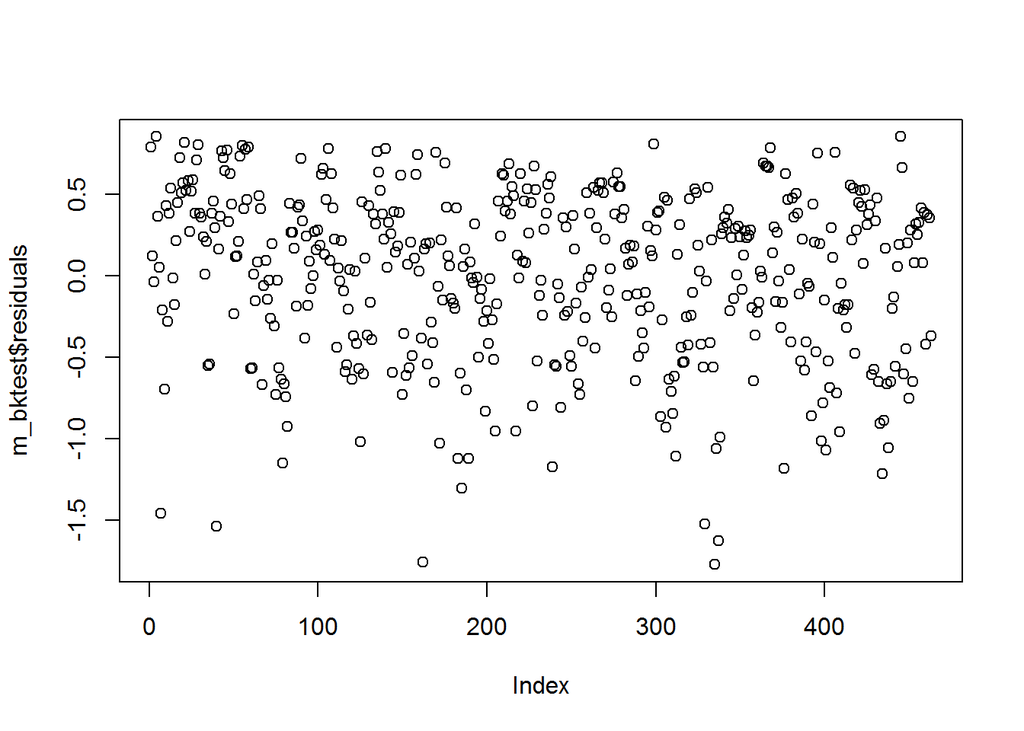

```r
m_bktest <- lm(score ~ gender + cls_perc_eval + cls_credits +  pic_color, data = evals)
plot(m_bktest$residuals)
```

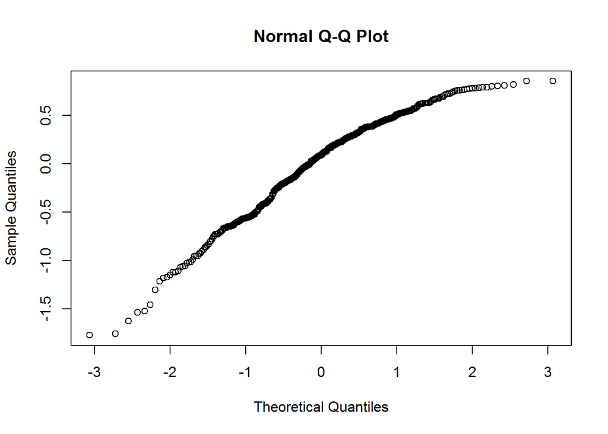

```r
qqnorm(m_bktest$residuals)
```

**Answer : From the residual plot we can dee that the conditions for Linear model like residuals being homoscadastic and nearly normally distributed are not truely satisfied here**

17. The original paper describes how these data were gathered by taking a sample of professors from the University of Texas at Austin and including all courses that they have taught. Considering that each row represents a course, could this new information have an impact on any of the conditions of linear regression?

**Answer : Since the sample represents only one location, it is same as adding a constant value to the model input. This will not be very useful information for the model to predict the avg teachers score and will not make any difference**

18. Based on your final model, describe the characteristics of a professor and course at University of Texas at Austin that would be associated with a high evaluation score.

19. Would you be comfortable generalizing your conclusions to apply to professors generally (at any university)? Why or why not?

**Based on this study, I wouldn’t be comfortable to ganearalize these results to any university. Sample just represents very specific university (University of Texas in Austin). Sample is not randomized and doesn’t represent overall population of the students and teachers from nationwide universities. This can be very biased sample and could reveal a trend of a very specific university targetted in this observational study. However to generalize the results we need to make our sampling strategy more comprehensive and unbiased. Observation collected should be randomized and should be true representation of the overall population for us to generalize the results. From the model output we can see that the conditions for linear model are not fully satisfied in the result. We don’t have a very strong conclusion whether identified important variables are truely doing good job in predicting the outcome variable. That is also one of the factor contributing towards not generalizing the result of this observational study**

This is a product of OpenIntro that is released under a [Creative Commons Attribution-ShareAlike 3.0 Unported](http://creativecommons.org/licenses/by-sa/3.0). This lab was written by Mine Çetinkaya-Rundel and Andrew Bray.